# Food_Hub_Project

```python
# import libraries for data manipulation
import numpy as np
import pandas as pd

# import libraries for data visualization
import matplotlib.pyplot as plt
import seaborn as sns
%matplotlib inline

#Load the Data
df= pd.read_csv('/content/foodhub_order.csv')
df.head()
```

|  | order_id | customer_id | restaurant_name | cuisine_type | cost_of_the_order | day_of_the_week | rating | food_preparation_time | delivery_time |
| --- | --- | --- | --- | --- | --- | --- | --- | --- | --- |
| 0 | 1477147 | 337525 | Hangawi | Korean | 30.75 | Weekend | Not given | 25 | 20 |
| 1 | 1477685 | 358141 | Blue Ribbon Sushi Izakaya | Japanese | 12.08 | Weekend | Not given | 25 | 23 |
| 2 | 1477070 | 66393 | Cafe Habana | Mexican | 12.23 | Weekday | 5 | 23 | 28 |
| 3 | 1477334 | 106968 | Blue Ribbon Fried Chicken | American | 29.20 | Weekend | 3 | 25 | 15 |
| 4 | 1478249 | 76942 | Dirty Bird to Go | American | 11.59 | Weekday | 4 | 25 | 24 |

```python
#How many rows and columns? 1898 rows and 9 columns
df.shape
```

```
(1898, 9)
```

```python
#What are the datatypes of the different columns in the dataset? (The info() function can be used) [0.5 mark]
df.info()
```

```
<class 'pandas.core.frame.DataFrame'>
RangeIndex: 1898 entries, 0 to 1897
Data columns (total 9 columns):
 #   Column                 Non-Null Count  Dtype
---  ------                 --------------  -----
 0   order_id               1898 non-null   int64
 1   customer_id            1898 non-null   int64
 2   restaurant_name        1898 non-null   object
 3   cuisine_type           1898 non-null   object
 4   cost_of_the_order      1898 non-null   float64
 5   day_of_the_week        1898 non-null   object
 6   rating                 1898 non-null   object
 7   food_preparation_time  1898 non-null   int64
 8   delivery_time          1898 non-null   int64
dtypes: float64(1), int64(4), object(4)
memory usage: 133.6+ KB
```

```python
#Are there any missing values in the data? If yes, treat them using an appropriate method. [1 mark]
missing_values = df.isnull().sum()
missing_values
```

```
order_id                 0
customer_id              0
restaurant_name          0
cuisine_type             0
cost_of_the_order        0
day_of_the_week          0
rating                   0
food_preparation_time    0
delivery_time            0
dtype: int64
```

```python
df['rating'].unique()
```

```
array(['Not given', '5', '3', '4'], dtype=object)
```

```python
#Drop "Not given" string in rating column
df = df[~df['rating'].str.contains('Not given')]
df.reset_index(drop=True, inplace=True)
```

```python
#Check the statistical summary of the data. What is the minimum, average, and maximum time it takes for food to be prepared once an order is placed?
df.describe().T
```

|  | count | mean | std | min | 25% | 50% | 75% | max |
| --- | --- | --- | --- | --- | --- | --- | --- | --- |
| order_id | 1162.0 | 1.477520e+06 | 546.871297 | 1476547.00 | 1477062.25 | 1477523.5 | 1477991.75 | 1478444.00 |
| customer_id | 1162.0 | 1.719395e+05 | 114551.215031 | 5139.00 | 77540.00 | 128655.5 | 276066.25 | 403019.00 |
| cost_of_the_order | 1162.0 | 1.676077e+01 | 7.572578 | 4.47 | 12.13 | 14.6 | 22.75 | 35.41 |
| food_preparation_time | 1162.0 | 2.738124e+01 | 4.677922 | 20.00 | 23.00 | 27.0 | 32.00 | 35.00 |
| delivery_time | 1162.0 | 2.415404e+01 | 4.930999 | 15.00 | 20.00 | 25.0 | 28.00 | 33.00 |

The min, average and max time it takes for food to be prepared are 20, 27.4 and 35

```python
df['food_preparation_time'].min()
```

```
20
```

```python
df['food_preparation_time'].mean()
```

[output not shown]

```python
df['food_preparation_time'].max()
```

```
35
```

```python
#How many orders are not rated?
df['rating'].isnull().sum()
```

```
0
```

```python
#Duplicate Check
df.duplicated().sum()
```

```
0
```

Univariate Analysis

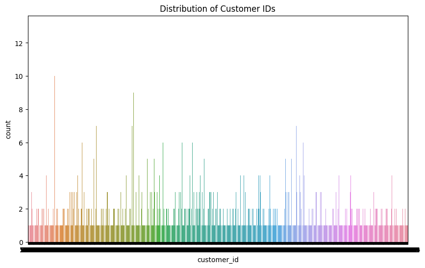

```python
#Distribution of customers
plt.figure(figsize=(10, 6))
sns.countplot(data=df, x='customer_id')
plt.title('Distribution of Customer IDs')
plt.show()
```

[figure not shown]

```python
plt.figure(figsize=(12, 6))
sns.countplot(data=df, x='cuisine_type', palette='YlGnBu')
plt.xticks(rotation=90)
plt.title('Distribution of Cuisine Types')
plt.show()
```

[figure not shown]

```python
#Let's explore the cost of the order
plt.figure(figsize=(8, 6))
sns.histplot(df['cost_of_the_order'], bins=18, kde=True)
plt.xlabel('Order Costs')
plt.ylabel('Frequency')
plt.title('Distribution of Order Costs')
plt.show()
```

[figure not shown]

```python
sns.countplot(data=df, x= 'food_preparation_time')
```

[figure not shown]

```python
#Distribution of Delivery Time
sns.histplot(df['delivery_time'], bins=20, kde=True)
plt.xlabel('Delivery Time (minutes)')
plt.ylabel('Frequency')
plt.title('Distribution of Delivery Time')
plt.show()
```

[figure not shown]

```python
#Distribution of orders by day_of_the_week
plt.figure(figsize=(6, 4))
sns.countplot(data=df, x='day_of_the_week', palette='Blues')
plt.xlabel('Day of the Week')
plt.ylabel('Count')
plt.title('Distribution of Weekly Orders')
plt.show()
```

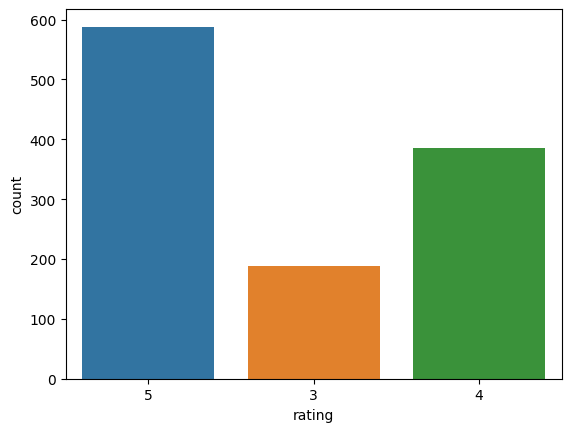

```python
#Rating Distribution
sns.countplot(data=df, x= 'rating')
```

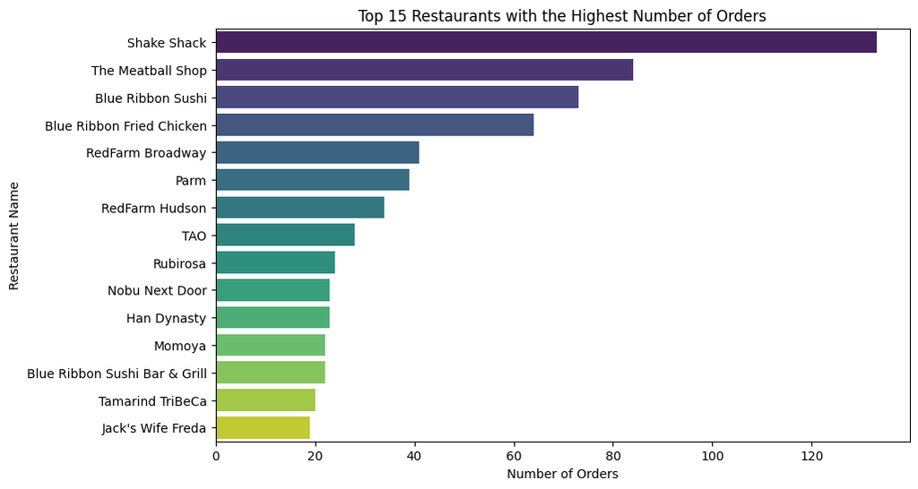

```python
#Distribution of restaurants with the highest orders
top_restaurants = df['restaurant_name'].value_counts().nlargest(15)
plt.figure(figsize=(10, 6))
sns.barplot(x=top_restaurants.values, y=top_restaurants.index, palette='viridis')
plt.xlabel('Number of Orders')
plt.ylabel('Restaurant Name')
plt.title('Top 15 Restaurants with the Highest Number of Orders')
plt.show()
```

```python
#Question 7: Which are the top 5 restaurants in terms of the number of orders received?
restaurant_order = df['restaurant_name'].value_counts()
top_restaurants= restaurant_order.head(5)
print(top_restaurants)
```

[output not shown]

```python
#Which is the most popular cuisine on weekends?
Cuisine =df['cuisine_type'].value_counts()
Popular_Cuisine= Cuisine.head(1)
print(Popular_Cuisine)
```

[output not shown]

```python
#What percentage of the orders cost more than 20 dollars?
total_orders = len(df)
cost_above_20 = len(df[df['cost_of_the_order'] > 20])

percentage_above_20 = (cost_above_20 / total_orders) * 100
print(f"Percentage of orders costing more than $20: {percentage_above_20:.2f}%")
```

```
Percentage of orders costing more than $20: 29.24%
```

```python
#What is the mean order delivery time?
delivery_time_mean= df['delivery_time'].mean()
print(delivery_time_mean)
```

[output not shown]

```python
#The company has decided to give 20% discount vouchers to the top 3 most frequent customers. Find the IDs of these customers and the number of orders they placed.
```

```python
customer_order_counts = df['customer_id'].value_counts()
top_3_customers = customer_order_counts.head(3)
print(top_3_customers)
```

```
52832    13
47440    10
83287     9
Name: customer_id, dtype: int64
```

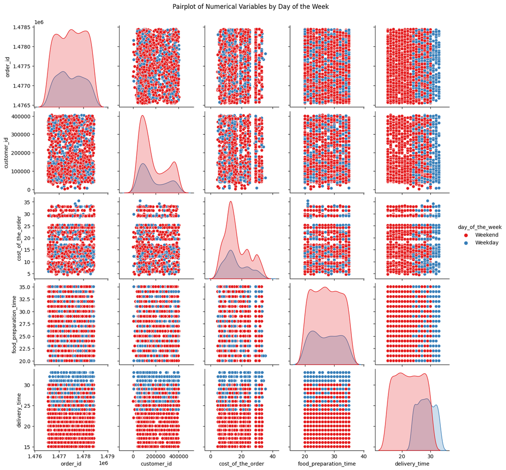

```python
#Multivariate Analysis
#Pairplot of numerical values by day of the week
sns.pairplot(df, hue='day_of_the_week', palette='Set1')
plt.suptitle("Pairplot of Numerical Variables by Day of the Week", y=1.02)
plt.show()
```

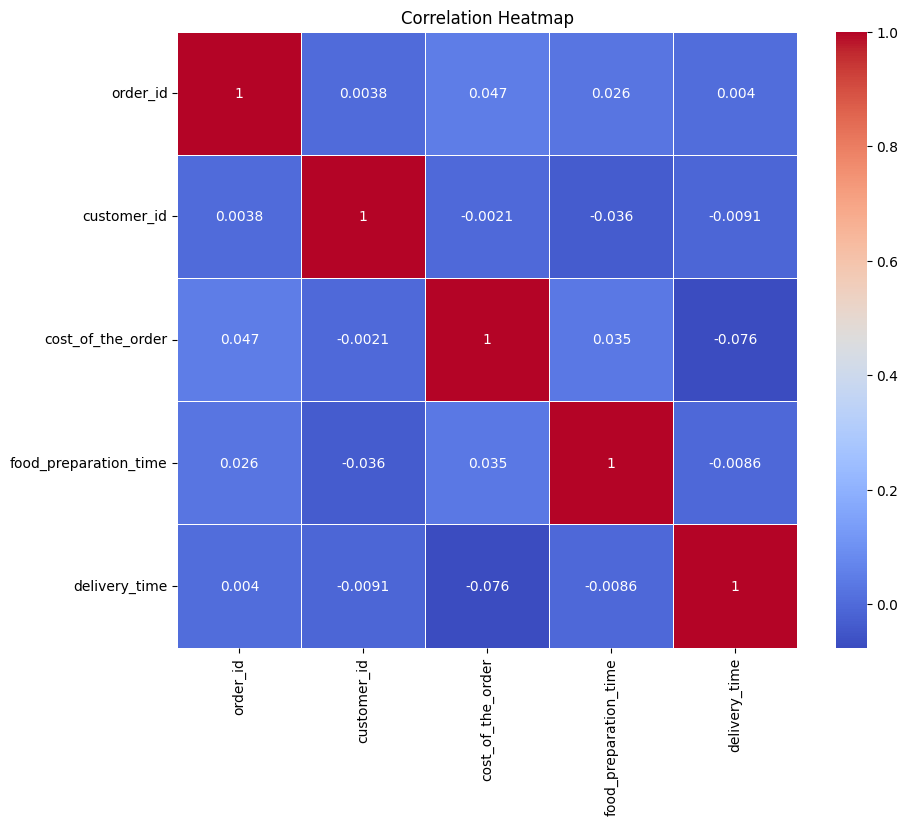

```python
# Heatmap to visualize correlations between all numerical variables
correlation_matrix = df.corr()
plt.figure(figsize=(10, 8))
sns.heatmap(correlation_matrix, annot=True, cmap='coolwarm', linewidths=0.5)
plt.title('Correlation Heatmap')
plt.show()
```

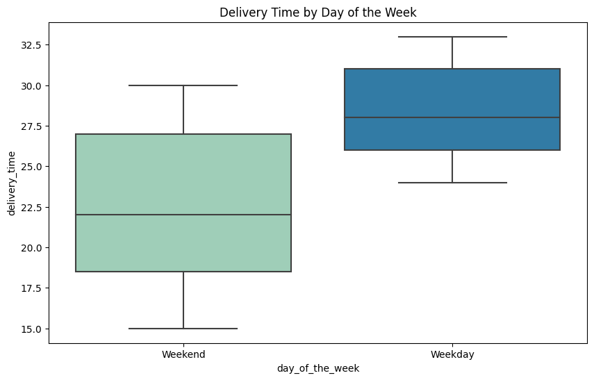

```python
# Box plots to visualize relationships between delivery and the day of the week
plt.figure(figsize=(10, 6))
sns.boxplot(data=df, x='day_of_the_week', y='delivery_time', palette='YlGnBu')
plt.title('Delivery Time by Day of the Week')
plt.show()
```

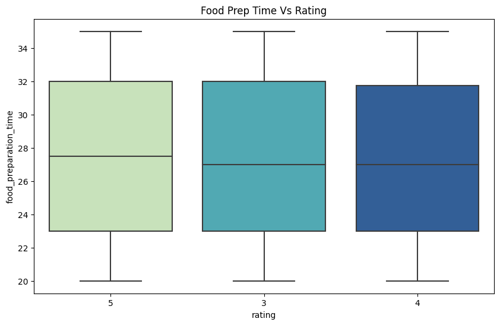

```python
#   visualize the relationship between rating and food preparation time
plt.figure(figsize=(10, 6))
sns.boxplot(data=df, x='rating', y='food_preparation_time', palette='YlGnBu')
plt.title('Food Prep Time Vs Rating')
plt.show()
```

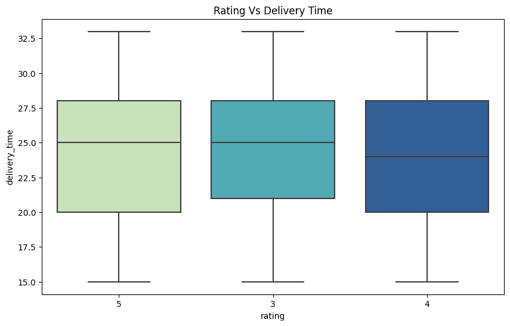

```python
# box plots to visualize the relationship between rating and delivery time
plt.figure(figsize=(10, 6))
sns.boxplot(data=df, x='rating', y='delivery_time', palette='YlGnBu')
plt.title('Rating Vs Delivery Time')
plt.show()
```

```python
#Drop "Not given" string in rating column
df = df[~df['rating'].str.contains('Not given')]
df.reset_index(drop=True, inplace=True)
```

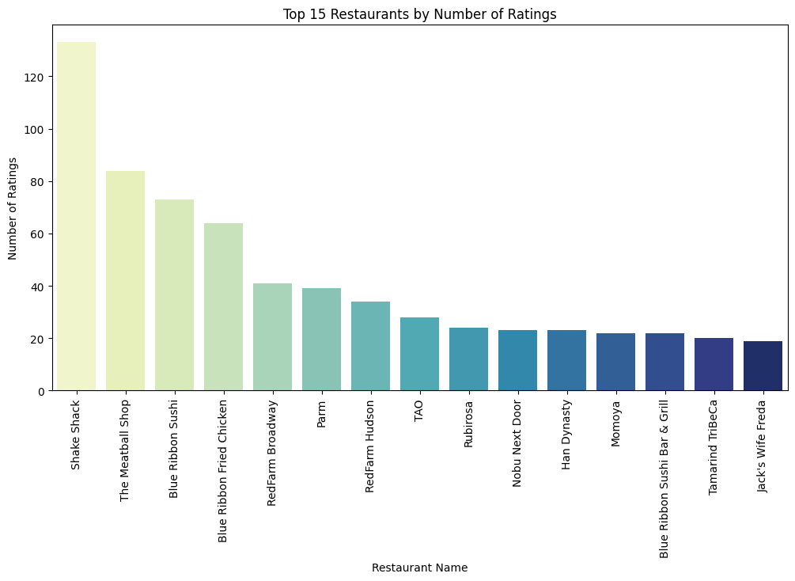

```python
#Visualization of the top 15 restaurants based on Ratings
#Group Restaurants
restaurant_ratings = df.groupby('restaurant_name')['rating'].agg(['mean', 'count'])
restaurant_ratings = restaurant_ratings.rename(columns={'mean': 'avg_rating', 'count': 'num_ratings'})

# Sort the restaurants by the number of ratings in descending order
top_restaurants = restaurant_ratings.sort_values(by='num_ratings', ascending=False).head(15)

# Create a bar plot to visualize the top restaurants by number of ratings
plt.figure(figsize=(12, 6))
sns.barplot(x=top_restaurants.index, y=top_restaurants['num_ratings'], palette='YlGnBu')
plt.xticks(rotation=90)
plt.xlabel('Restaurant Name')
plt.ylabel('Number of Ratings')
plt.title('Top 15 Restaurants by Number of Ratings')
plt.show()
```

```python
#Drop "Not given" string in rating column
df = df[~df['rating'].str.contains('Not given')]
df.reset_index(drop=True, inplace=True)
```

```python
#Restaurants Eligible for Offer
# Group restaurants and calculate total number of ratings and the average rating
restaurant_stats = df.groupby('restaurant_name').agg({'rating': ['mean', 'count']}).reset_index()

# Rename the columns for clarity
restaurant_stats.columns = ['restaurant_name', 'average_rating', 'rating_count']

# Filter Eligible Restaurants
eligible_restaurants = restaurant_stats[(restaurant_stats['rating_count'] > 50) & (restaurant_stats['average_rating'] > 4)]
print("Restaurants eligible for the promotional offer:")
print(eligible_restaurants)
```

```
Restaurants eligible for the promotional offer:
               restaurant_name  average_rating  rating_count
16   Blue Ribbon Fried Chicken    5.552274e+61            64
17           Blue Ribbon Sushi    6.089773e+70            73
117                Shake Shack   4.177018e+130           133
132          The Meatball Shop    6.494697e+81            84
```

```python
#Question 14
# Calculate revenue for each order based on the cost and the percentage charge
def calculate_revenue(cost_of_the_order):
    if cost_of_the_order > 20:
        return cost_of_the_order * 0.25
    elif cost_of_the_order > 5:
        return cost_of_the_order * 0.15
    else:
        return 0

# Apply the calculate_revenue function to each row in the DataFrame
df['revenue'] = df['cost_of_the_order'].apply(calculate_revenue)

# Calculate the total net revenue generated by the company
total_net_revenue = df['revenue'].sum()

# Print the total net revenue
print(f'Total Net Revenue: ${total_net_revenue:.2f}')
```

```
Total Net Revenue: $3865.57
```

```python
#Question 15
df['total_time'] = df['food_preparation_time'] + df['delivery_time']
percentage_above_60_minutes = (len(df[df['total_time'] > 60]) / len(df)) * 100

# Print the percentage
print(percentage_above_60_minutes)
```

```
10.240963855421686
```

```python
#Question 16
# Group the data by 'day_of_the_week' and calculate the mean delivery time
mean_delivery_time_by_day = df.groupby('day_of_the_week')['delivery_time'].mean()

# Print the result
print(mean_delivery_time_by_day)
```

```
day_of_the_week
Weekday    28.305882
Weekend    22.436740
Name: delivery_time, dtype: float64
```

Conclusions:

Revenue and Profitability: Understanding the correlation between food preparation time and order frequency is crucial for revenue and profitability analysis.

Recommendations:

Rating Matrix: Implement a separate rating matrix for delivery services to better capture customer feedback. Consider using smiley ratings or reminders to improve rating participation.

Operational Efficiency: Streamline food preparation and delivery processes to reduce wait times and improve resource allocation. Consider day-of-the-week factors and prioritize restaurants with high order volumes.

Diversify Client Base: Expand to regions with diverse populations to increase sales of other cuisine types and restaurants. Collaborate with restaurants to diversify menu offerings and cater to a broader audience.

Promote Popular Restaurants: Use special offers, discounts, and marketing campaigns to promote highly-rated and popular restaurants, attracting more customers.

```python
!pip install nbconvert
```